# Risk Factor Analysis

## Outcome Variable

**Outcome Variable:** whz

## Predictor Variables

**Intervention Variable:** mbmi

**Adjustment Set:**

- arm
- W_mage
- meducyrs
- feducyrs
- single
- brthmon
- W_parity
- delta_W_mage
- delta_meducyrs
- delta_feducyrs
- delta_single
- delta_brthmon
- delta_W_parity

## Stratifying Variables

The analysis was stratified on these variable(s):

- agecat
- studyid
- country

## Data Summary

| agecat | studyid | country | mbmi | n_cell | n |
| --- | --- | --- | --- | --- | --- |
| Birth | JiVitA-3 | BANGLADESH | Normal weight | 10934 | 17935 |
| Birth | JiVitA-3 | BANGLADESH | Underweight | 7001 | 17935 |
| Birth | MAL-ED | BANGLADESH | Normal weight | 183 | 209 |
| Birth | MAL-ED | BANGLADESH | Underweight | 26 | 209 |
| Birth | MAL-ED | BRAZIL | Normal weight | 56 | 61 |
| Birth | MAL-ED | BRAZIL | Underweight | 5 | 61 |
| Birth | MAL-ED | INDIA | Normal weight | 33 | 41 |
| Birth | MAL-ED | INDIA | Underweight | 8 | 41 |
| Birth | MAL-ED | NEPAL | Normal weight | 26 | 26 |
| Birth | MAL-ED | NEPAL | Underweight | 0 | 26 |
| Birth | MAL-ED | PERU | Normal weight | 216 | 221 |
| Birth | MAL-ED | PERU | Underweight | 5 | 221 |
| Birth | MAL-ED | SOUTH AFRICA | Normal weight | 97 | 100 |
| Birth | MAL-ED | SOUTH AFRICA | Underweight | 3 | 100 |
| Birth | MAL-ED | TANZANIA, UNITED REPUBLIC OF | Normal weight | 107 | 113 |
| Birth | MAL-ED | TANZANIA, UNITED REPUBLIC OF | Underweight | 6 | 113 |
| Birth | NIH-Birth | BANGLADESH | Normal weight | 483 | 575 |
| Birth | NIH-Birth | BANGLADESH | Underweight | 92 | 575 |
| Birth | NIH-Crypto | BANGLADESH | Normal weight | 639 | 704 |
| Birth | NIH-Crypto | BANGLADESH | Underweight | 65 | 704 |
| Birth | PROBIT | BELARUS | Normal weight | 13130 | 13651 |
| Birth | PROBIT | BELARUS | Underweight | 521 | 13651 |
| Birth | PROVIDE | BANGLADESH | Normal weight | 411 | 510 |
| Birth | PROVIDE | BANGLADESH | Underweight | 99 | 510 |
| Birth | SAS-CompFeed | INDIA | Normal weight | 735 | 992 |
| Birth | SAS-CompFeed | INDIA | Underweight | 257 | 992 |
| Birth | ZVITAMBO | ZIMBABWE | Normal weight | 8574 | 9030 |
| Birth | ZVITAMBO | ZIMBABWE | Underweight | 456 | 9030 |
| 6 months | JiVitA-3 | BANGLADESH | Normal weight | 10303 | 16733 |
| 6 months | JiVitA-3 | BANGLADESH | Underweight | 6430 | 16733 |

[output cut: 60 more lines]

The following strata were considered:

- agecat: 24 months, studyid: JiVitA-3, country: BANGLADESH
- agecat: 24 months, studyid: LCNI-5, country: MALAWI
- agecat: 24 months, studyid: MAL-ED, country: BANGLADESH
- agecat: 24 months, studyid: MAL-ED, country: BRAZIL
- agecat: 24 months, studyid: MAL-ED, country: INDIA
- agecat: 24 months, studyid: MAL-ED, country: NEPAL
- agecat: 24 months, studyid: MAL-ED, country: PERU
- agecat: 24 months, studyid: MAL-ED, country: SOUTH AFRICA
- agecat: 24 months, studyid: MAL-ED, country: TANZANIA, UNITED REPUBLIC OF
- agecat: 24 months, studyid: NIH-Birth, country: BANGLADESH
- agecat: 24 months, studyid: NIH-Crypto, country: BANGLADESH
- agecat: 24 months, studyid: PROBIT, country: BELARUS
- agecat: 24 months, studyid: PROVIDE, country: BANGLADESH
- agecat: 24 months, studyid: TanzaniaChild2, country: TANZANIA, UNITED REPUBLIC OF
- agecat: 24 months, studyid: ZVITAMBO, country: ZIMBABWE
- agecat: 6 months, studyid: JiVitA-3, country: BANGLADESH
- agecat: 6 months, studyid: LCNI-5, country: MALAWI
- agecat: 6 months, studyid: MAL-ED, country: BANGLADESH
- agecat: 6 months, studyid: MAL-ED, country: BRAZIL
- agecat: 6 months, studyid: MAL-ED, country: INDIA
- agecat: 6 months, studyid: MAL-ED, country: NEPAL
- agecat: 6 months, studyid: MAL-ED, country: PERU
- agecat: 6 months, studyid: MAL-ED, country: SOUTH AFRICA
- agecat: 6 months, studyid: MAL-ED, country: TANZANIA, UNITED REPUBLIC OF
- agecat: 6 months, studyid: NIH-Birth, country: BANGLADESH
- agecat: 6 months, studyid: NIH-Crypto, country: BANGLADESH
- agecat: 6 months, studyid: PROBIT, country: BELARUS
- agecat: 6 months, studyid: PROVIDE, country: BANGLADESH
- agecat: 6 months, studyid: SAS-CompFeed, country: INDIA
- agecat: 6 months, studyid: TanzaniaChild2, country: TANZANIA, UNITED REPUBLIC OF
- agecat: 6 months, studyid: ZVITAMBO, country: ZIMBABWE
- agecat: Birth, studyid: JiVitA-3, country: BANGLADESH
- agecat: Birth, studyid: MAL-ED, country: BANGLADESH
- agecat: Birth, studyid: MAL-ED, country: BRAZIL
- agecat: Birth, studyid: MAL-ED, country: INDIA
- agecat: Birth, studyid: MAL-ED, country: NEPAL
- agecat: Birth, studyid: MAL-ED, country: PERU
- agecat: Birth, studyid: MAL-ED, country: SOUTH AFRICA
- agecat: Birth, studyid: MAL-ED, country: TANZANIA, UNITED REPUBLIC OF
- agecat: Birth, studyid: NIH-Birth, country: BANGLADESH
- agecat: Birth, studyid: NIH-Crypto, country: BANGLADESH
- agecat: Birth, studyid: PROBIT, country: BELARUS
- agecat: Birth, studyid: PROVIDE, country: BANGLADESH
- agecat: Birth, studyid: SAS-CompFeed, country: INDIA
- agecat: Birth, studyid: ZVITAMBO, country: ZIMBABWE

### Dropped Strata

Some strata were dropped due to rare outcomes:

- agecat: Birth, studyid: MAL-ED, country: NEPAL
- agecat: Birth, studyid: MAL-ED, country: SOUTH AFRICA
- agecat: 6 months, studyid: MAL-ED, country: NEPAL
- agecat: 24 months, studyid: MAL-ED, country: NEPAL
- agecat: 24 months, studyid: MAL-ED, country: PERU
- agecat: 24 months, studyid: TanzaniaChild2, country: TANZANIA, UNITED REPUBLIC OF

## Methods Detail

We’re interested in the causal parameters $E[Y_a]$ for all values of $a \in \mathcal{A}$. These parameters represent the mean outcome if, possibly contrary to fact, we intervened to set all units to have $A=a$. Under the randomization and positivity assumptions, these are identified by the statistical parameters $\psi_a=E_W[E_{Y|A,W}(Y|A=a,W)]$. In addition, we’re interested in the mean of $Y$, $E[Y]$ under no intervention (the observed mean). We will estimate these parameters by using SuperLearner to fit the relevant likelihood factors – $E_{Y|A,W}(Y|A=a,W)$ and $p(A=a|W)$, and then updating our likelihood fit using a joint TMLE.

For unadjusted analyses ($W=\{\}$), initial likelihoods were estimated using Lrnr_glm to estimate the simple $E(Y|A)$ and Lrnr_mean to estimate $p(A)$. For adjusted analyses, a small library containing Lrnr_glmnet, Lrnr_xgboost, and Lrnr_mean was used.

Having estimated these parameters, we will then use the delta method to estimate relative risks and attributable risks relative to a prespecified baseline level of $A$.

# Results Detail

## Results Plots

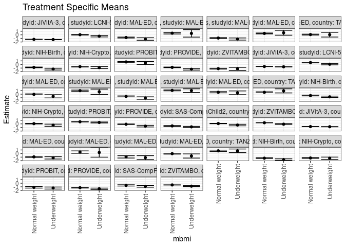

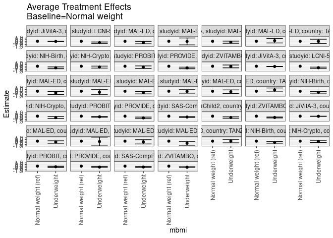

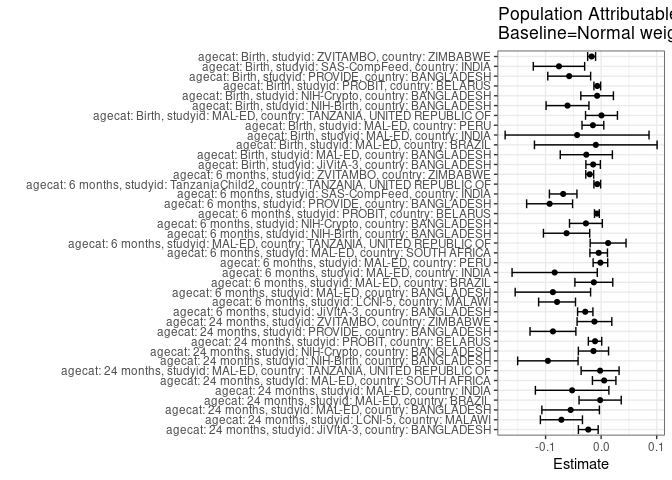

## Results Table

### Parameter: TSM

| agecat | studyid | country | intervention_level | baseline_level | estimate | ci_lower | ci_upper |
| --- | --- | --- | --- | --- | --- | --- | --- |
| Birth | JiVitA-3 | BANGLADESH | Normal weight | NA | -0.7637940 | -0.7871017 | -0.7404863 |
| Birth | JiVitA-3 | BANGLADESH | Underweight | NA | -0.7999672 | -0.8275443 | -0.7723901 |
| Birth | MAL-ED | BANGLADESH | Normal weight | NA | -0.9266985 | -1.0856529 | -0.7677441 |
| Birth | MAL-ED | BANGLADESH | Underweight | NA | -1.2003438 | -1.5284111 | -0.8722765 |
| Birth | MAL-ED | BRAZIL | Normal weight | NA | 0.4114286 | 0.0848121 | 0.7380451 |
| Birth | MAL-ED | BRAZIL | Underweight | NA | 0.2940000 | -1.0086888 | 1.5966888 |
| Birth | MAL-ED | INDIA | Normal weight | NA | -0.9245455 | -1.2487999 | -0.6002910 |
| Birth | MAL-ED | INDIA | Underweight | NA | -1.1462500 | -1.7084286 | -0.5840714 |
| Birth | MAL-ED | PERU | Normal weight | NA | -0.0281944 | -0.1526241 | 0.0962352 |
| Birth | MAL-ED | PERU | Underweight | NA | -0.6820000 | -1.2614133 | -0.1025867 |
| Birth | MAL-ED | TANZANIA, UNITED REPUBLIC OF | Normal weight | NA | 0.7576636 | 0.5539948 | 0.9613323 |
| Birth | MAL-ED | TANZANIA, UNITED REPUBLIC OF | Underweight | NA | 0.7700000 | 0.2691531 | 1.2708469 |
| Birth | NIH-Birth | BANGLADESH | Normal weight | NA | -1.2894087 | -1.3943411 | -1.1844762 |
| Birth | NIH-Birth | BANGLADESH | Underweight | NA | -1.6754096 | -1.8899960 | -1.4608233 |
| Birth | NIH-Crypto | BANGLADESH | Normal weight | NA | -1.2362652 | -1.3247350 | -1.1477955 |
| Birth | NIH-Crypto | BANGLADESH | Underweight | NA | -1.3220431 | -1.6518612 | -0.9922251 |
| Birth | PROBIT | BELARUS | Normal weight | NA | -1.1403342 | -1.3507132 | -0.9299553 |
| Birth | PROBIT | BELARUS | Underweight | NA | -1.3442145 | -1.6279100 | -1.0605191 |
| Birth | PROVIDE | BANGLADESH | Normal weight | NA | -1.2486336 | -1.3352494 | -1.1620179 |
| Birth | PROVIDE | BANGLADESH | Underweight | NA | -1.5390745 | -1.7218270 | -1.3563220 |
| Birth | SAS-CompFeed | INDIA | Normal weight | NA | -0.5993547 | -0.7761424 | -0.4225670 |
| Birth | SAS-CompFeed | INDIA | Underweight | NA | -0.8766507 | -1.1045877 | -0.6487138 |
| Birth | ZVITAMBO | ZIMBABWE | Normal weight | NA | -0.4734457 | -0.5051992 | -0.4416922 |
| Birth | ZVITAMBO | ZIMBABWE | Underweight | NA | -0.8131132 | -0.9521392 | -0.6740871 |
| 6 months | JiVitA-3 | BANGLADESH | Normal weight | NA | -0.5645884 | -0.5874839 | -0.5416930 |
| 6 months | JiVitA-3 | BANGLADESH | Underweight | NA | -0.6383265 | -0.6693095 | -0.6073435 |
| 6 months | LCNI-5 | MALAWI | Normal weight | NA | 0.5308626 | 0.4527721 | 0.6089531 |
| 6 months | LCNI-5 | MALAWI | Underweight | NA | 0.0716869 | -0.0906786 | 0.2340525 |
| 6 months | MAL-ED | BANGLADESH | Normal weight | NA | -0.0508364 | -0.1794159 | 0.0777431 |
| 6 months | MAL-ED | BANGLADESH | Underweight | NA | -0.5946098 | -1.0452215 | -0.1439981 |
| 6 months | MAL-ED | BRAZIL | Normal weight | NA | 0.9779606 | 0.8096461 | 1.1462751 |
| 6 months | MAL-ED | BRAZIL | Underweight | NA | 0.6750000 | -0.0698801 | 1.4198801 |
| 6 months | MAL-ED | INDIA | Normal weight | NA | -0.6197989 | -0.7521590 | -0.4874389 |
| 6 months | MAL-ED | INDIA | Underweight | NA | -1.0828605 | -1.4219788 | -0.7437421 |
| 6 months | MAL-ED | PERU | Normal weight | NA | 1.0561298 | 0.9317231 | 1.1805366 |
| 6 months | MAL-ED | PERU | Underweight | NA | 0.9870000 | 0.4781587 | 1.4958413 |
| 6 months | MAL-ED | SOUTH AFRICA | Normal weight | NA | 0.5335468 | 0.3758513 | 0.6912424 |
| 6 months | MAL-ED | SOUTH AFRICA | Underweight | NA | 0.3771429 | -0.1498294 | 0.9041151 |
| 6 months | MAL-ED | TANZANIA, UNITED REPUBLIC OF | Normal weight | NA | 0.5236588 | 0.3883911 | 0.6589266 |
| 6 months | MAL-ED | TANZANIA, UNITED REPUBLIC OF | Underweight | NA | 0.9191681 | 0.3484693 | 1.4898669 |
| 6 months | NIH-Birth | BANGLADESH | Normal weight | NA | -0.3851833 | -0.4845807 | -0.2857859 |
| 6 months | NIH-Birth | BANGLADESH | Underweight | NA | -0.7456313 | -0.9556050 | -0.5356576 |
| 6 months | NIH-Crypto | BANGLADESH | Normal weight | NA | 0.0571490 | -0.0256497 | 0.1399477 |
| 6 months | NIH-Crypto | BANGLADESH | Underweight | NA | -0.3798453 | -0.6827703 | -0.0769202 |
| 6 months | PROBIT | BELARUS | Normal weight | NA | 0.5861550 | 0.5280660 | 0.6442439 |
| 6 months | PROBIT | BELARUS | Underweight | NA | 0.3939555 | 0.2631603 | 0.5247507 |
| 6 months | PROVIDE | BANGLADESH | Normal weight | NA | -0.1059991 | -0.1955991 | -0.0163992 |
| 6 months | PROVIDE | BANGLADESH | Underweight | NA | -0.6358770 | -0.8604462 | -0.4113078 |
| 6 months | SAS-CompFeed | INDIA | Normal weight | NA | -0.5743315 | -0.7120177 | -0.4366453 |
| 6 months | SAS-CompFeed | INDIA | Underweight | NA | -0.8362207 | -0.9702569 | -0.7021845 |
| 6 months | TanzaniaChild2 | TANZANIA, UNITED REPUBLIC OF | Normal weight | NA | 0.0844545 | 0.0301002 | 0.1388088 |
| 6 months | TanzaniaChild2 | TANZANIA, UNITED REPUBLIC OF | Underweight | NA | -0.3298627 | -0.5423111 | -0.1174143 |
| 6 months | ZVITAMBO | ZIMBABWE | Normal weight | NA | 0.3153530 | 0.2872119 | 0.3434940 |
| 6 months | ZVITAMBO | ZIMBABWE | Underweight | NA | -0.0873961 | -0.2273675 | 0.0525752 |
| 24 months | JiVitA-3 | BANGLADESH | Normal weight | NA | -1.2739678 | -1.3033323 | -1.2446033 |
| 24 months | JiVitA-3 | BANGLADESH | Underweight | NA | -1.3349826 | -1.3716096 | -1.2983556 |
| 24 months | LCNI-5 | MALAWI | Normal weight | NA | 0.0245923 | -0.0645489 | 0.1137335 |
| 24 months | LCNI-5 | MALAWI | Underweight | NA | -0.3980522 | -0.5911438 | -0.2049605 |
| 24 months | MAL-ED | BANGLADESH | Normal weight | NA | -0.7643956 | -0.8949214 | -0.6338699 |
| 24 months | MAL-ED | BANGLADESH | Underweight | NA | -1.1736904 | -1.5210920 | -0.8262888 |
| 24 months | MAL-ED | BRAZIL | Normal weight | NA | 0.4461317 | 0.2381826 | 0.6540808 |
| 24 months | MAL-ED | BRAZIL | Underweight | NA | 0.3966667 | -0.6451983 | 1.4385316 |
| 24 months | MAL-ED | INDIA | Normal weight | NA | -0.8997425 | -1.0236670 | -0.7758180 |
| 24 months | MAL-ED | INDIA | Underweight | NA | -1.1749279 | -1.4746344 | -0.8752215 |
| 24 months | MAL-ED | SOUTH AFRICA | Normal weight | NA | 0.3861417 | 0.2630585 | 0.5092249 |
| 24 months | MAL-ED | SOUTH AFRICA | Underweight | NA | 0.5700000 | -0.1123856 | 1.2523856 |
| 24 months | MAL-ED | TANZANIA, UNITED REPUBLIC OF | Normal weight | NA | 0.0566387 | -0.0707065 | 0.1839838 |
| 24 months | MAL-ED | TANZANIA, UNITED REPUBLIC OF | Underweight | NA | 0.0326068 | -0.6232317 | 0.6884453 |
| 24 months | NIH-Birth | BANGLADESH | Normal weight | NA | -0.8157095 | -0.9189876 | -0.7124313 |
| 24 months | NIH-Birth | BANGLADESH | Underweight | NA | -1.2972688 | -1.5488311 | -1.0457066 |
| 24 months | NIH-Crypto | BANGLADESH | Normal weight | NA | -0.5965652 | -0.6956579 | -0.4974726 |
| 24 months | NIH-Crypto | BANGLADESH | Underweight | NA | -0.8666211 | -1.1553017 | -0.5779405 |
| 24 months | PROBIT | BELARUS | Normal weight | NA | 0.7100966 | 0.5977621 | 0.8224310 |
| 24 months | PROBIT | BELARUS | Underweight | NA | 0.4244530 | -0.0033092 | 0.8522152 |
| 24 months | PROVIDE | BANGLADESH | Normal weight | NA | -0.8047340 | -0.8944987 | -0.7149692 |
| 24 months | PROVIDE | BANGLADESH | Underweight | NA | -1.3334740 | -1.5620910 | -1.1048569 |
| 24 months | ZVITAMBO | ZIMBABWE | Normal weight | NA | -1.1598497 | -1.2731001 | -1.0465993 |
| 24 months | ZVITAMBO | ZIMBABWE | Underweight | NA | -1.2203090 | -1.6394354 | -0.8011825 |

### Parameter: E(Y)

| agecat | studyid | country | intervention_level | baseline_level | estimate | ci_lower | ci_upper |
| --- | --- | --- | --- | --- | --- | --- | --- |
| Birth | JiVitA-3 | BANGLADESH | NA | NA | -0.7781583 | -0.7971779 | -0.7591388 |
| Birth | MAL-ED | BANGLADESH | NA | NA | -0.9533493 | -1.0984355 | -0.8082631 |
| Birth | MAL-ED | BRAZIL | NA | NA | 0.4018033 | 0.0834093 | 0.7201973 |
| Birth | MAL-ED | INDIA | NA | NA | -0.9678049 | -1.2522118 | -0.6833979 |
| Birth | MAL-ED | PERU | NA | NA | -0.0429864 | -0.1658406 | 0.0798678 |
| Birth | MAL-ED | TANZANIA, UNITED REPUBLIC OF | NA | NA | 0.7583186 | 0.5636385 | 0.9529987 |
| Birth | NIH-Birth | BANGLADESH | NA | NA | -1.3499217 | -1.4444634 | -1.2553801 |
| Birth | NIH-Crypto | BANGLADESH | NA | NA | -1.2434730 | -1.3276901 | -1.1592559 |
| Birth | PROBIT | BELARUS | NA | NA | -1.1472584 | -1.3582745 | -0.9362424 |
| Birth | PROVIDE | BANGLADESH | NA | NA | -1.3060980 | -1.3843247 | -1.2278714 |
| Birth | SAS-CompFeed | INDIA | NA | NA | -0.6752218 | -0.8548888 | -0.4955547 |
| Birth | ZVITAMBO | ZIMBABWE | NA | NA | -0.4905338 | -0.5214551 | -0.4596125 |
| 6 months | JiVitA-3 | BANGLADESH | NA | NA | -0.5931545 | -0.6127055 | -0.5736036 |
| 6 months | LCNI-5 | MALAWI | NA | NA | 0.4515550 | 0.3802638 | 0.5228463 |
| 6 months | MAL-ED | BANGLADESH | NA | NA | -0.1376763 | -0.2664642 | -0.0088885 |
| 6 months | MAL-ED | BRAZIL | NA | NA | 0.9648518 | 0.8004118 | 1.1292917 |
| 6 months | MAL-ED | INDIA | NA | NA | -0.7034149 | -0.8300527 | -0.5767771 |
| 6 months | MAL-ED | PERU | NA | NA | 1.0548591 | 0.9328922 | 1.1768259 |
| 6 months | MAL-ED | SOUTH AFRICA | NA | NA | 0.5291499 | 0.3751396 | 0.6831602 |
| 6 months | MAL-ED | TANZANIA, UNITED REPUBLIC OF | NA | NA | 0.5362213 | 0.4049390 | 0.6675036 |
| 6 months | NIH-Birth | BANGLADESH | NA | NA | -0.4474038 | -0.5378167 | -0.3569909 |
| 6 months | NIH-Crypto | BANGLADESH | NA | NA | 0.0297622 | -0.0491685 | 0.1086930 |
| 6 months | PROBIT | BELARUS | NA | NA | 0.5785149 | 0.5197782 | 0.6372516 |
| 6 months | PROVIDE | BANGLADESH | NA | NA | -0.1987071 | -0.2815473 | -0.1158669 |
| 6 months | SAS-CompFeed | INDIA | NA | NA | -0.6426305 | -0.7702214 | -0.5150396 |
| 6 months | TanzaniaChild2 | TANZANIA, UNITED REPUBLIC OF | NA | NA | 0.0775172 | 0.0241750 | 0.1308595 |
| 6 months | ZVITAMBO | ZIMBABWE | NA | NA | 0.2948332 | 0.2672524 | 0.3224139 |
| 24 months | JiVitA-3 | BANGLADESH | NA | NA | -1.2970642 | -1.3203662 | -1.2737621 |
| 24 months | LCNI-5 | MALAWI | NA | NA | -0.0468717 | -0.1290135 | 0.0352701 |
| 24 months | MAL-ED | BANGLADESH | NA | NA | -0.8192925 | -0.9412667 | -0.6973182 |
| 24 months | MAL-ED | BRAZIL | NA | NA | 0.4443651 | 0.2404149 | 0.6483153 |
| 24 months | MAL-ED | INDIA | NA | NA | -0.9519248 | -1.0678488 | -0.8360007 |
| 24 months | MAL-ED | SOUTH AFRICA | NA | NA | 0.3916417 | 0.2704414 | 0.5128421 |
| 24 months | MAL-ED | TANZANIA, UNITED REPUBLIC OF | NA | NA | 0.0547975 | -0.0703378 | 0.1799328 |
| 24 months | NIH-Birth | BANGLADESH | NA | NA | -0.9115790 | -1.0095022 | -0.8136559 |
| 24 months | NIH-Crypto | BANGLADESH | NA | NA | -0.6103502 | -0.7050157 | -0.5156847 |
| 24 months | PROBIT | BELARUS | NA | NA | 0.6991214 | 0.5821715 | 0.8160713 |
| 24 months | PROVIDE | BANGLADESH | NA | NA | -0.8914360 | -0.9741797 | -0.8086923 |
| 24 months | ZVITAMBO | ZIMBABWE | NA | NA | -1.1718579 | -1.2809898 | -1.0627260 |

### Parameter: ATE

| agecat | studyid | country | intervention_level | baseline_level | estimate | ci_lower | ci_upper |
| --- | --- | --- | --- | --- | --- | --- | --- |
| Birth | JiVitA-3 | BANGLADESH | Normal weight | Normal weight | 0.0000000 | 0.0000000 | 0.0000000 |
| Birth | JiVitA-3 | BANGLADESH | Underweight | Normal weight | -0.0361732 | -0.0695636 | -0.0027828 |
| Birth | MAL-ED | BANGLADESH | Normal weight | Normal weight | 0.0000000 | 0.0000000 | 0.0000000 |
| Birth | MAL-ED | BANGLADESH | Underweight | Normal weight | -0.2736453 | -0.6394834 | 0.0921928 |
| Birth | MAL-ED | BRAZIL | Normal weight | Normal weight | 0.0000000 | 0.0000000 | 0.0000000 |
| Birth | MAL-ED | BRAZIL | Underweight | Normal weight | -0.1174286 | -1.4604388 | 1.2255816 |
| Birth | MAL-ED | INDIA | Normal weight | Normal weight | 0.0000000 | 0.0000000 | 0.0000000 |
| Birth | MAL-ED | INDIA | Underweight | Normal weight | -0.2217045 | -0.8706928 | 0.4272837 |
| Birth | MAL-ED | PERU | Normal weight | Normal weight | 0.0000000 | 0.0000000 | 0.0000000 |
| Birth | MAL-ED | PERU | Underweight | Normal weight | -0.6538056 | -1.2464290 | -0.0611821 |
| Birth | MAL-ED | TANZANIA, UNITED REPUBLIC OF | Normal weight | Normal weight | 0.0000000 | 0.0000000 | 0.0000000 |
| Birth | MAL-ED | TANZANIA, UNITED REPUBLIC OF | Underweight | Normal weight | 0.0123364 | -0.5283378 | 0.5530107 |
| Birth | NIH-Birth | BANGLADESH | Normal weight | Normal weight | 0.0000000 | 0.0000000 | 0.0000000 |
| Birth | NIH-Birth | BANGLADESH | Underweight | Normal weight | -0.3860010 | -0.6248708 | -0.1471311 |
| Birth | NIH-Crypto | BANGLADESH | Normal weight | Normal weight | 0.0000000 | 0.0000000 | 0.0000000 |
| Birth | NIH-Crypto | BANGLADESH | Underweight | Normal weight | -0.0857779 | -0.4277147 | 0.2561588 |
| Birth | PROBIT | BELARUS | Normal weight | Normal weight | 0.0000000 | 0.0000000 | 0.0000000 |
| Birth | PROBIT | BELARUS | Underweight | Normal weight | -0.2038803 | -0.3698407 | -0.0379199 |
| Birth | PROVIDE | BANGLADESH | Normal weight | Normal weight | 0.0000000 | 0.0000000 | 0.0000000 |
| Birth | PROVIDE | BANGLADESH | Underweight | Normal weight | -0.2904409 | -0.4927751 | -0.0881067 |
| Birth | SAS-CompFeed | INDIA | Normal weight | Normal weight | 0.0000000 | 0.0000000 | 0.0000000 |
| Birth | SAS-CompFeed | INDIA | Underweight | Normal weight | -0.2772960 | -0.4591349 | -0.0954572 |
| Birth | ZVITAMBO | ZIMBABWE | Normal weight | Normal weight | 0.0000000 | 0.0000000 | 0.0000000 |
| Birth | ZVITAMBO | ZIMBABWE | Underweight | Normal weight | -0.3396675 | -0.4822618 | -0.1970731 |
| 6 months | JiVitA-3 | BANGLADESH | Normal weight | Normal weight | 0.0000000 | 0.0000000 | 0.0000000 |
| 6 months | JiVitA-3 | BANGLADESH | Underweight | Normal weight | -0.0737381 | -0.1098545 | -0.0376217 |
| 6 months | LCNI-5 | MALAWI | Normal weight | Normal weight | 0.0000000 | 0.0000000 | 0.0000000 |
| 6 months | LCNI-5 | MALAWI | Underweight | Normal weight | -0.4591757 | -0.6394636 | -0.2788877 |
| 6 months | MAL-ED | BANGLADESH | Normal weight | Normal weight | 0.0000000 | 0.0000000 | 0.0000000 |
| 6 months | MAL-ED | BANGLADESH | Underweight | Normal weight | -0.5437734 | -1.0128036 | -0.0747433 |
| 6 months | MAL-ED | BRAZIL | Normal weight | Normal weight | 0.0000000 | 0.0000000 | 0.0000000 |
| 6 months | MAL-ED | BRAZIL | Underweight | Normal weight | -0.3029606 | -1.0666204 | 0.4606991 |
| 6 months | MAL-ED | INDIA | Normal weight | Normal weight | 0.0000000 | 0.0000000 | 0.0000000 |
| 6 months | MAL-ED | INDIA | Underweight | Normal weight | -0.4630615 | -0.8284948 | -0.0976283 |
| 6 months | MAL-ED | PERU | Normal weight | Normal weight | 0.0000000 | 0.0000000 | 0.0000000 |
| 6 months | MAL-ED | PERU | Underweight | Normal weight | -0.0691298 | -0.5929586 | 0.4546989 |
| 6 months | MAL-ED | SOUTH AFRICA | Normal weight | Normal weight | 0.0000000 | 0.0000000 | 0.0000000 |
| 6 months | MAL-ED | SOUTH AFRICA | Underweight | Normal weight | -0.1564040 | -0.7064654 | 0.3936575 |
| 6 months | MAL-ED | TANZANIA, UNITED REPUBLIC OF | Normal weight | Normal weight | 0.0000000 | 0.0000000 | 0.0000000 |
| 6 months | MAL-ED | TANZANIA, UNITED REPUBLIC OF | Underweight | Normal weight | 0.3955093 | -0.1913117 | 0.9823303 |
| 6 months | NIH-Birth | BANGLADESH | Normal weight | Normal weight | 0.0000000 | 0.0000000 | 0.0000000 |
| 6 months | NIH-Birth | BANGLADESH | Underweight | Normal weight | -0.3604480 | -0.5927963 | -0.1280997 |
| 6 months | NIH-Crypto | BANGLADESH | Normal weight | Normal weight | 0.0000000 | 0.0000000 | 0.0000000 |
| 6 months | NIH-Crypto | BANGLADESH | Underweight | Normal weight | -0.4369943 | -0.7511902 | -0.1227984 |
| 6 months | PROBIT | BELARUS | Normal weight | Normal weight | 0.0000000 | 0.0000000 | 0.0000000 |
| 6 months | PROBIT | BELARUS | Underweight | Normal weight | -0.1921994 | -0.3054391 | -0.0789597 |
| 6 months | PROVIDE | BANGLADESH | Normal weight | Normal weight | 0.0000000 | 0.0000000 | 0.0000000 |
| 6 months | PROVIDE | BANGLADESH | Underweight | Normal weight | -0.5298778 | -0.7721700 | -0.2875857 |
| 6 months | SAS-CompFeed | INDIA | Normal weight | Normal weight | 0.0000000 | 0.0000000 | 0.0000000 |
| 6 months | SAS-CompFeed | INDIA | Underweight | Normal weight | -0.2618892 | -0.3644431 | -0.1593353 |
| 6 months | TanzaniaChild2 | TANZANIA, UNITED REPUBLIC OF | Normal weight | Normal weight | 0.0000000 | 0.0000000 | 0.0000000 |
| 6 months | TanzaniaChild2 | TANZANIA, UNITED REPUBLIC OF | Underweight | Normal weight | -0.4143172 | -0.6331755 | -0.1954590 |
| 6 months | ZVITAMBO | ZIMBABWE | Normal weight | Normal weight | 0.0000000 | 0.0000000 | 0.0000000 |
| 6 months | ZVITAMBO | ZIMBABWE | Underweight | Normal weight | -0.4027491 | -0.5454520 | -0.2600463 |
| 24 months | JiVitA-3 | BANGLADESH | Normal weight | Normal weight | 0.0000000 | 0.0000000 | 0.0000000 |
| 24 months | JiVitA-3 | BANGLADESH | Underweight | Normal weight | -0.0610148 | -0.1072234 | -0.0148062 |
| 24 months | LCNI-5 | MALAWI | Normal weight | Normal weight | 0.0000000 | 0.0000000 | 0.0000000 |
| 24 months | LCNI-5 | MALAWI | Underweight | Normal weight | -0.4226445 | -0.6347556 | -0.2105333 |
| 24 months | MAL-ED | BANGLADESH | Normal weight | Normal weight | 0.0000000 | 0.0000000 | 0.0000000 |
| 24 months | MAL-ED | BANGLADESH | Underweight | Normal weight | -0.4092947 | -0.7817419 | -0.0368476 |
| 24 months | MAL-ED | BRAZIL | Normal weight | Normal weight | 0.0000000 | 0.0000000 | 0.0000000 |
| 24 months | MAL-ED | BRAZIL | Underweight | Normal weight | -0.0494650 | -1.1118799 | 1.0129498 |
| 24 months | MAL-ED | INDIA | Normal weight | Normal weight | 0.0000000 | 0.0000000 | 0.0000000 |
| 24 months | MAL-ED | INDIA | Underweight | Normal weight | -0.2751854 | -0.6001049 | 0.0497340 |
| 24 months | MAL-ED | SOUTH AFRICA | Normal weight | Normal weight | 0.0000000 | 0.0000000 | 0.0000000 |
| 24 months | MAL-ED | SOUTH AFRICA | Underweight | Normal weight | 0.1838583 | -0.5095388 | 0.8772554 |
| 24 months | MAL-ED | TANZANIA, UNITED REPUBLIC OF | Normal weight | Normal weight | 0.0000000 | 0.0000000 | 0.0000000 |
| 24 months | MAL-ED | TANZANIA, UNITED REPUBLIC OF | Underweight | Normal weight | -0.0240319 | -0.6927256 | 0.6446618 |
| 24 months | NIH-Birth | BANGLADESH | Normal weight | Normal weight | 0.0000000 | 0.0000000 | 0.0000000 |
| 24 months | NIH-Birth | BANGLADESH | Underweight | Normal weight | -0.4815594 | -0.7544034 | -0.2087154 |
| 24 months | NIH-Crypto | BANGLADESH | Normal weight | Normal weight | 0.0000000 | 0.0000000 | 0.0000000 |
| 24 months | NIH-Crypto | BANGLADESH | Underweight | Normal weight | -0.2700559 | -0.5753514 | 0.0352395 |
| 24 months | PROBIT | BELARUS | Normal weight | Normal weight | 0.0000000 | 0.0000000 | 0.0000000 |
| 24 months | PROBIT | BELARUS | Underweight | Normal weight | -0.2856435 | -0.6644047 | 0.0931176 |
| 24 months | PROVIDE | BANGLADESH | Normal weight | Normal weight | 0.0000000 | 0.0000000 | 0.0000000 |
| 24 months | PROVIDE | BANGLADESH | Underweight | Normal weight | -0.5287400 | -0.7741914 | -0.2832886 |
| 24 months | ZVITAMBO | ZIMBABWE | Normal weight | Normal weight | 0.0000000 | 0.0000000 | 0.0000000 |
| 24 months | ZVITAMBO | ZIMBABWE | Underweight | Normal weight | -0.0604593 | -0.4947855 | 0.3738670 |

### Parameter: PAR

| agecat | studyid | country | intervention_level | baseline_level | estimate | ci_lower | ci_upper |
| --- | --- | --- | --- | --- | --- | --- | --- |
| Birth | JiVitA-3 | BANGLADESH | Normal weight | NA | -0.0143644 | -0.0274166 | -0.0013121 |
| Birth | MAL-ED | BANGLADESH | Normal weight | NA | -0.0266508 | -0.0735721 | 0.0202706 |
| Birth | MAL-ED | BRAZIL | Normal weight | NA | -0.0096253 | -0.1200094 | 0.1007588 |
| Birth | MAL-ED | INDIA | Normal weight | NA | -0.0432594 | -0.1727854 | 0.0862665 |
| Birth | MAL-ED | PERU | Normal weight | NA | -0.0147920 | -0.0344019 | 0.0048180 |
| Birth | MAL-ED | TANZANIA, UNITED REPUBLIC OF | Normal weight | NA | 0.0006550 | -0.0280579 | 0.0293680 |
| Birth | NIH-Birth | BANGLADESH | Normal weight | NA | -0.0605131 | -0.0991063 | -0.0219199 |
| Birth | NIH-Crypto | BANGLADESH | Normal weight | NA | -0.0072078 | -0.0365611 | 0.0221455 |
| Birth | PROBIT | BELARUS | Normal weight | NA | -0.0069242 | -0.0129794 | -0.0008690 |
| Birth | PROVIDE | BANGLADESH | Normal weight | NA | -0.0574644 | -0.0960461 | -0.0188827 |
| Birth | SAS-CompFeed | INDIA | Normal weight | NA | -0.0758670 | -0.1220849 | -0.0296492 |
| Birth | ZVITAMBO | ZIMBABWE | Normal weight | NA | -0.0170881 | -0.0242180 | -0.0099582 |
| 6 months | JiVitA-3 | BANGLADESH | Normal weight | NA | -0.0285661 | -0.0423616 | -0.0147706 |
| 6 months | LCNI-5 | MALAWI | Normal weight | NA | -0.0793076 | -0.1125005 | -0.0461147 |
| 6 months | MAL-ED | BANGLADESH | Normal weight | NA | -0.0868400 | -0.1547160 | -0.0189639 |
| 6 months | MAL-ED | BRAZIL | Normal weight | NA | -0.0131089 | -0.0472021 | 0.0209844 |
| 6 months | MAL-ED | INDIA | Normal weight | NA | -0.0836160 | -0.1603211 | -0.0069109 |
| 6 months | MAL-ED | PERU | Normal weight | NA | -0.0012708 | -0.0144131 | 0.0118715 |
| 6 months | MAL-ED | SOUTH AFRICA | Normal weight | NA | -0.0043969 | -0.0201917 | 0.0113979 |
| 6 months | MAL-ED | TANZANIA, UNITED REPUBLIC OF | Normal weight | NA | 0.0125625 | -0.0197176 | 0.0448426 |
| 6 months | NIH-Birth | BANGLADESH | Normal weight | NA | -0.0622205 | -0.1038447 | -0.0205963 |
| 6 months | NIH-Crypto | BANGLADESH | Normal weight | NA | -0.0273868 | -0.0569369 | 0.0021634 |
| 6 months | PROBIT | BELARUS | Normal weight | NA | -0.0076400 | -0.0119540 | -0.0033261 |
| 6 months | PROVIDE | BANGLADESH | Normal weight | NA | -0.0927079 | -0.1340797 | -0.0513362 |
| 6 months | SAS-CompFeed | INDIA | Normal weight | NA | -0.0682990 | -0.0930723 | -0.0435257 |
| 6 months | TanzaniaChild2 | TANZANIA, UNITED REPUBLIC OF | Normal weight | NA | -0.0069373 | -0.0129918 | -0.0008828 |
| 6 months | ZVITAMBO | ZIMBABWE | Normal weight | NA | -0.0205198 | -0.0276140 | -0.0134256 |
| 24 months | JiVitA-3 | BANGLADESH | Normal weight | NA | -0.0230964 | -0.0408817 | -0.0053110 |
| 24 months | LCNI-5 | MALAWI | Normal weight | NA | -0.0714640 | -0.1093374 | -0.0335905 |
| 24 months | MAL-ED | BANGLADESH | Normal weight | NA | -0.0548968 | -0.1066898 | -0.0031038 |
| 24 months | MAL-ED | BRAZIL | Normal weight | NA | -0.0017666 | -0.0397355 | 0.0362023 |
| 24 months | MAL-ED | INDIA | Normal weight | NA | -0.0521823 | -0.1183268 | 0.0139623 |
| 24 months | MAL-ED | SOUTH AFRICA | Normal weight | NA | 0.0055000 | -0.0156289 | 0.0266289 |
| 24 months | MAL-ED | TANZANIA, UNITED REPUBLIC OF | Normal weight | NA | -0.0018412 | -0.0359843 | 0.0323019 |
| 24 months | NIH-Birth | BANGLADESH | Normal weight | NA | -0.0958696 | -0.1502500 | -0.0414892 |
| 24 months | NIH-Crypto | BANGLADESH | Normal weight | NA | -0.0137850 | -0.0409490 | 0.0133790 |
| 24 months | PROBIT | BELARUS | Normal weight | NA | -0.0109752 | -0.0230023 | 0.0010520 |
| 24 months | PROVIDE | BANGLADESH | Normal weight | NA | -0.0867020 | -0.1279681 | -0.0454359 |
| 24 months | ZVITAMBO | ZIMBABWE | Normal weight | NA | -0.0120082 | -0.0432545 | 0.0192380 |